# Lesson 01 Pandasを使ってみよう

[pandasのDataFrameの概要と生成方法 | hydroculのメモ](https://hydrocul.github.io/wiki/numpy/pandas-dataframe-overview.html)  
pandasにはSeriesとDataFrameという2つのデータ構造があり、 Seriesは1次元配列に似ているのに対して、 DataFrameは2次元配列というかエクセルのようなスプレッドシートに似ている。

```python
import pandas as pd
```

## 1. データフレームにcsvファイルを読み込む

```python
csv_file_name = 'data/WA_Fn-UseC_-HR-Employee-Attrition.csv'

df = pd.read_csv(csv_file_name)
df.head()
```

|  | Age | Attrition | BusinessTravel | DailyRate | Department | DistanceFromHome | Education | EducationField | EmployeeCount | EmployeeNumber | ... | RelationshipSatisfaction | StandardHours | StockOptionLevel | TotalWorkingYears | TrainingTimesLastYear | WorkLifeBalance | YearsAtCompany | YearsInCurrentRole | YearsSinceLastPromotion | YearsWithCurrManager |
| --- | --- | --- | --- | --- | --- | --- | --- | --- | --- | --- | --- | --- | --- | --- | --- | --- | --- | --- | --- | --- | --- |
| 0 | 41 | Yes | Travel_Rarely | 1102 | Sales | 1 | 2 | Life Sciences | 1 | 1 | ... | 1 | 80 | 0 | 8 | 0 | 1 | 6 | 4 | 0 | 5 |
| 1 | 49 | No | Travel_Frequently | 279 | Research & Development | 8 | 1 | Life Sciences | 1 | 2 | ... | 4 | 80 | 1 | 10 | 3 | 3 | 10 | 7 | 1 | 7 |
| 2 | 37 | Yes | Travel_Rarely | 1373 | Research & Development | 2 | 2 | Other | 1 | 4 | ... | 2 | 80 | 0 | 7 | 3 | 3 | 0 | 0 | 0 | 0 |
| 3 | 33 | No | Travel_Frequently | 1392 | Research & Development | 3 | 4 | Life Sciences | 1 | 5 | ... | 3 | 80 | 0 | 8 | 3 | 3 | 8 | 7 | 3 | 0 |
| 4 | 27 | No | Travel_Rarely | 591 | Research & Development | 2 | 1 | Medical | 1 | 7 | ... | 4 | 80 | 1 | 6 | 3 | 3 | 2 | 2 | 2 | 2 |

5 rows × 35 columns

## 2. データフレームにxlsxファイルを読み込む

- 以下のどれでも、dfに1シート目が割り当てられます。

### 2.1 pd.ExcelFile(...)

```python
xlsx_file_name = 'data/WA_Fn-UseC_-HR-Employee-Attrition.xlsx'

xl = pd.ExcelFile(xlsx_file_name)
xl.sheet_names
```

```
['WA_Fn-UseC_-HR-Employee-Attriti', 'Data Definitions']
```

```python
df = xl.parse('WA_Fn-UseC_-HR-Employee-Attriti')
df.head()
```

|  | Age | Attrition | BusinessTravel | DailyRate | Department | DistanceFromHome | Education | EducationField | EmployeeCount | EmployeeNumber | ... | RelationshipSatisfaction | StandardHours | StockOptionLevel | TotalWorkingYears | TrainingTimesLastYear | WorkLifeBalance | YearsAtCompany | YearsInCurrentRole | YearsSinceLastPromotion | YearsWithCurrManager |
| --- | --- | --- | --- | --- | --- | --- | --- | --- | --- | --- | --- | --- | --- | --- | --- | --- | --- | --- | --- | --- | --- |
| 0 | 41 | Yes | Travel_Rarely | 1102 | Sales | 1 | 2 | Life Sciences | 1 | 1 | ... | 1 | 80 | 0 | 8 | 0 | 1 | 6 | 4 | 0 | 5 |
| 1 | 49 | No | Travel_Frequently | 279 | Research & Development | 8 | 1 | Life Sciences | 1 | 2 | ... | 4 | 80 | 1 | 10 | 3 | 3 | 10 | 7 | 1 | 7 |
| 2 | 37 | Yes | Travel_Rarely | 1373 | Research & Development | 2 | 2 | Other | 1 | 4 | ... | 2 | 80 | 0 | 7 | 3 | 3 | 0 | 0 | 0 | 0 |
| 3 | 33 | No | Travel_Frequently | 1392 | Research & Development | 3 | 4 | Life Sciences | 1 | 5 | ... | 3 | 80 | 0 | 8 | 3 | 3 | 8 | 7 | 3 | 0 |
| 4 | 27 | No | Travel_Rarely | 591 | Research & Development | 2 | 1 | Medical | 1 | 7 | ... | 4 | 80 | 1 | 6 | 3 | 3 | 2 | 2 | 2 | 2 |

5 rows × 35 columns

```python
df = xl.parse(xl.sheet_names[0])
df.head()
```

|  | Age | Attrition | BusinessTravel | DailyRate | Department | DistanceFromHome | Education | EducationField | EmployeeCount | EmployeeNumber | ... | RelationshipSatisfaction | StandardHours | StockOptionLevel | TotalWorkingYears | TrainingTimesLastYear | WorkLifeBalance | YearsAtCompany | YearsInCurrentRole | YearsSinceLastPromotion | YearsWithCurrManager |
| --- | --- | --- | --- | --- | --- | --- | --- | --- | --- | --- | --- | --- | --- | --- | --- | --- | --- | --- | --- | --- | --- |
| 0 | 41 | Yes | Travel_Rarely | 1102 | Sales | 1 | 2 | Life Sciences | 1 | 1 | ... | 1 | 80 | 0 | 8 | 0 | 1 | 6 | 4 | 0 | 5 |
| 1 | 49 | No | Travel_Frequently | 279 | Research & Development | 8 | 1 | Life Sciences | 1 | 2 | ... | 4 | 80 | 1 | 10 | 3 | 3 | 10 | 7 | 1 | 7 |
| 2 | 37 | Yes | Travel_Rarely | 1373 | Research & Development | 2 | 2 | Other | 1 | 4 | ... | 2 | 80 | 0 | 7 | 3 | 3 | 0 | 0 | 0 | 0 |
| 3 | 33 | No | Travel_Frequently | 1392 | Research & Development | 3 | 4 | Life Sciences | 1 | 5 | ... | 3 | 80 | 0 | 8 | 3 | 3 | 8 | 7 | 3 | 0 |
| 4 | 27 | No | Travel_Rarely | 591 | Research & Development | 2 | 1 | Medical | 1 | 7 | ... | 4 | 80 | 1 | 6 | 3 | 3 | 2 | 2 | 2 | 2 |

5 rows × 35 columns

### 2.2 pd.read_excel(...)

```python
df = pd.read_excel(xlsx_file_name, sheetname = 'WA_Fn-UseC_-HR-Employee-Attriti')
df.head()
```

|  | Age | Attrition | BusinessTravel | DailyRate | Department | DistanceFromHome | Education | EducationField | EmployeeCount | EmployeeNumber | ... | RelationshipSatisfaction | StandardHours | StockOptionLevel | TotalWorkingYears | TrainingTimesLastYear | WorkLifeBalance | YearsAtCompany | YearsInCurrentRole | YearsSinceLastPromotion | YearsWithCurrManager |
| --- | --- | --- | --- | --- | --- | --- | --- | --- | --- | --- | --- | --- | --- | --- | --- | --- | --- | --- | --- | --- | --- |
| 0 | 41 | Yes | Travel_Rarely | 1102 | Sales | 1 | 2 | Life Sciences | 1 | 1 | ... | 1 | 80 | 0 | 8 | 0 | 1 | 6 | 4 | 0 | 5 |
| 1 | 49 | No | Travel_Frequently | 279 | Research & Development | 8 | 1 | Life Sciences | 1 | 2 | ... | 4 | 80 | 1 | 10 | 3 | 3 | 10 | 7 | 1 | 7 |
| 2 | 37 | Yes | Travel_Rarely | 1373 | Research & Development | 2 | 2 | Other | 1 | 4 | ... | 2 | 80 | 0 | 7 | 3 | 3 | 0 | 0 | 0 | 0 |
| 3 | 33 | No | Travel_Frequently | 1392 | Research & Development | 3 | 4 | Life Sciences | 1 | 5 | ... | 3 | 80 | 0 | 8 | 3 | 3 | 8 | 7 | 3 | 0 |
| 4 | 27 | No | Travel_Rarely | 591 | Research & Development | 2 | 1 | Medical | 1 | 7 | ... | 4 | 80 | 1 | 6 | 3 | 3 | 2 | 2 | 2 | 2 |

5 rows × 35 columns

```python
df = pd.read_excel(xlsx_file_name)
df.head()
```

|  | Age | Attrition | BusinessTravel | DailyRate | Department | DistanceFromHome | Education | EducationField | EmployeeCount | EmployeeNumber | ... | RelationshipSatisfaction | StandardHours | StockOptionLevel | TotalWorkingYears | TrainingTimesLastYear | WorkLifeBalance | YearsAtCompany | YearsInCurrentRole | YearsSinceLastPromotion | YearsWithCurrManager |
| --- | --- | --- | --- | --- | --- | --- | --- | --- | --- | --- | --- | --- | --- | --- | --- | --- | --- | --- | --- | --- | --- |
| 0 | 41 | Yes | Travel_Rarely | 1102 | Sales | 1 | 2 | Life Sciences | 1 | 1 | ... | 1 | 80 | 0 | 8 | 0 | 1 | 6 | 4 | 0 | 5 |
| 1 | 49 | No | Travel_Frequently | 279 | Research & Development | 8 | 1 | Life Sciences | 1 | 2 | ... | 4 | 80 | 1 | 10 | 3 | 3 | 10 | 7 | 1 | 7 |
| 2 | 37 | Yes | Travel_Rarely | 1373 | Research & Development | 2 | 2 | Other | 1 | 4 | ... | 2 | 80 | 0 | 7 | 3 | 3 | 0 | 0 | 0 | 0 |
| 3 | 33 | No | Travel_Frequently | 1392 | Research & Development | 3 | 4 | Life Sciences | 1 | 5 | ... | 3 | 80 | 0 | 8 | 3 | 3 | 8 | 7 | 3 | 0 |
| 4 | 27 | No | Travel_Rarely | 591 | Research & Development | 2 | 1 | Medical | 1 | 7 | ... | 4 | 80 | 1 | 6 | 3 | 3 | 2 | 2 | 2 | 2 |

5 rows × 35 columns

[10分でPandasを学ぶ - Qiita](http://qiita.com/tkazusa/items/23bc0142bf277d397260)  
[Python Pandasでのデータ操作の初歩まとめ − 前半：データ作成＆操作編 - Qiita](http://qiita.com/hik0107/items/d991cc44c2d1778bb82e)

## 3. 行数の確認

```python
len(df)
```

```
1470
```

## 4. 次元数の確認

```python
df.shape #（行数、列数）の形で返す
```

```
(1470, 35)
```

## 5. データフレームの情報の一覧

```python
df.info() #カラム名とその型の一覧
```

```
<class 'pandas.core.frame.DataFrame'>
RangeIndex: 1470 entries, 0 to 1469
Data columns (total 35 columns):
Age                         1470 non-null int64
Attrition                   1470 non-null object
BusinessTravel              1470 non-null object
DailyRate                   1470 non-null int64
Department                  1470 non-null object
DistanceFromHome            1470 non-null int64
Education                   1470 non-null int64
EducationField              1470 non-null object
EmployeeCount               1470 non-null int64
EmployeeNumber              1470 non-null int64
EnvironmentSatisfaction     1470 non-null int64
Gender                      1470 non-null object
HourlyRate                  1470 non-null int64
JobInvolvement              1470 non-null int64
JobLevel                    1470 non-null int64
JobRole                     1470 non-null object
JobSatisfaction             1470 non-null int64
MaritalStatus               1470 non-null object
MonthlyIncome               1470 non-null int64
MonthlyRate                 1470 non-null int64
NumCompaniesWorked          1470 non-null int64
Over18                      1470 non-null object
OverTime                    1470 non-null object
PercentSalaryHike           1470 non-null int64
PerformanceRating           1470 non-null int64
RelationshipSatisfaction    1470 non-null int64
StandardHours               1470 non-null int64
StockOptionLevel            1470 non-null int64
TotalWorkingYears           1470 non-null int64
TrainingTimesLastYear       1470 non-null int64
WorkLifeBalance             1470 non-null int64
YearsAtCompany              1470 non-null int64
YearsInCurrentRole          1470 non-null int64
YearsSinceLastPromotion     1470 non-null int64
YearsWithCurrManager        1470 non-null int64
dtypes: int64(26), object(9)
memory usage: 402.0+ KB
```

## 6. ヒストグラム

### df.hist(...)

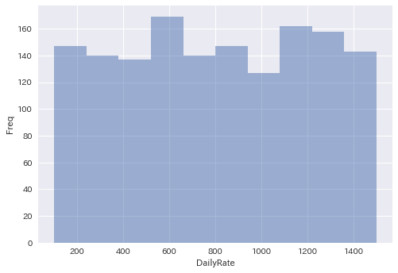

```python
import numpy as np
from pandas import *
import matplotlib.pyplot as plt
import seaborn as sns
sns.set(font='IPAexGothic')
df["DailyRate"].hist(linewidth = 1, alpha=.5)
plt.xlabel("DailyRate")
plt.ylabel("Freq")
plt.show()
```

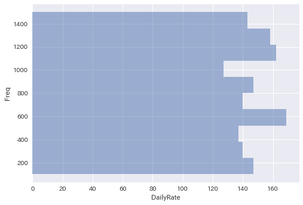

```python
import matplotlib.pyplot as plt
import seaborn as sns
sns.set(font='IPAexGothic')
df["DailyRate"].hist(orientation='horizontal', alpha=.5)
plt.xlabel("DailyRate")
plt.ylabel("Freq")
plt.show()
```

参考:

1. [Visualization — pandas 0.20.3 documentation](https://pandas.pydata.org/pandas-docs/stable/visualization.html)
2. [Visualizing the distribution of a dataset — seaborn 0.8.0 documentation](https://seaborn.pydata.org/tutorial/distributions.html)

## 7. 散布図

### plt.scatter(...)

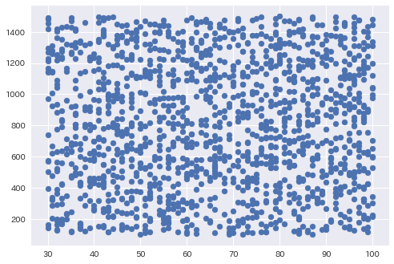

```python
plt.scatter(df['HourlyRate'], df['DailyRate'])
plt.show()
```

## 8. 多変量散布図

### pd.plotting.scatter_matrix(df, ...)

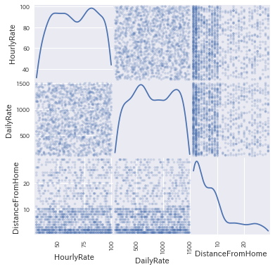

```python
pd.plotting.scatter_matrix(df[['HourlyRate', 'DailyRate', 'DistanceFromHome']], alpha=0.2, figsize=(6, 6), diagonal='kde')
plt.show()
```

[Computational tools — pandas 0.20.3 documentation](https://pandas.pydata.org/pandas-docs/stable/computation.html)

## 9. 共分散行列

```python
df[['HourlyRate', 'DailyRate', 'DistanceFromHome']].cov()
```

|  | HourlyRate | DailyRate | DistanceFromHome |
| --- | --- | --- | --- |
| HourlyRate | 413.285626 | 191.800350 | 5.130567 |
| DailyRate | 191.800350 | 162819.593737 | -16.308004 |
| DistanceFromHome | 5.130567 | -16.308004 | 65.721251 |

```python
df.cov()
```

|  | Age | DailyRate | DistanceFromHome | Education | EmployeeCount | EmployeeNumber | EnvironmentSatisfaction | HourlyRate | JobInvolvement | JobLevel | ... | RelationshipSatisfaction | StandardHours | StockOptionLevel | TotalWorkingYears | TrainingTimesLastYear | WorkLifeBalance | YearsAtCompany | YearsInCurrentRole | YearsSinceLastPromotion | YearsWithCurrManager |
| --- | --- | --- | --- | --- | --- | --- | --- | --- | --- | --- | --- | --- | --- | --- | --- | --- | --- | --- | --- | --- | --- |
| Age | 83.455049 | 39.298434 | -0.124873 | 1.946390 | 0.0 | -55.797199 | 0.101319 | 4.510422 | 0.193841 | 5.153276 | ... | 0.528776 | 0.0 | 0.291977 | 48.361684 | -0.231093 | -0.138695 | 17.423359 | 7.046750 | 6.373743 | 6.587332 |
| DailyRate | 39.298434 | 162819.593737 | -16.308004 | -6.945424 | 0.0 | -12386.713294 | 8.095750 | 191.800350 | 13.246309 | 1.324944 | ... | 3.423048 | 0.0 | 14.489565 | 45.570709 | 1.275892 | -10.789322 | -84.187085 | 14.520296 | -43.206982 | -37.957055 |
| DistanceFromHome | -0.124873 | -16.308004 | 65.721251 | 0.174705 | 0.0 | 160.649502 | -0.142451 | 5.130567 | 0.050667 | 0.047586 | ... | 0.057478 | 0.0 | 0.309961 | 0.291951 | -0.386118 | -0.152094 | 0.472219 | 0.553521 | 0.261991 | 0.416715 |
| Education | 1.946390 | -6.945424 | 0.174705 | 1.048914 | 0.0 | 25.939251 | -0.030370 | 0.349263 | 0.030927 | 0.115170 | ... | -0.010097 | 0.0 | 0.016076 | 1.181612 | -0.033143 | 0.007105 | 0.433659 | 0.223515 | 0.179056 | 0.252390 |
| EmployeeCount | 0.000000 | 0.000000 | 0.000000 | 0.000000 | 0.0 | 0.000000 | 0.000000 | 0.000000 | 0.000000 | 0.000000 | ... | 0.000000 | 0.0 | 0.000000 | 0.000000 | 0.000000 | 0.000000 | 0.000000 | 0.000000 | 0.000000 | 0.000000 |
| EmployeeNumber | -55.797199 | -12386.713294 | 160.649502 | 25.939251 | 0.0 | 362433.299749 | 11.595582 | 430.551701 | -2.950629 | -12.341279 | ... | -45.473775 | 0.0 | 31.920482 | -67.289749 | 18.320126 | 4.384426 | -41.458396 | -18.357800 | -17.496817 | -19.755358 |
| EnvironmentSatisfaction | 0.101319 | 8.095750 | -0.142451 | -0.030370 | 0.0 | 11.595582 | 1.194829 | -1.107908 | -0.006438 | 0.001466 | ... | 0.009059 | 0.0 | 0.003197 | -0.022905 | -0.027283 | 0.021335 | 0.009761 | 0.071317 | 0.057040 | -0.019496 |
| HourlyRate | 4.510422 | 191.800350 | 5.130567 | 0.349263 | 0.0 | 430.551701 | -1.107908 | 413.285626 | 0.620006 | -0.626800 | ... | 0.029244 | 0.0 | 0.870674 | -0.369139 | -0.224036 | -0.066170 | -2.438866 | -1.775575 | -1.750142 | -1.459700 |
| JobInvolvement | 0.193841 | 13.246309 | 0.050667 | 0.030927 | 0.0 | -2.950629 | -0.006438 | 0.620006 | 0.506319 | -0.009948 | ... | 0.026386 | 0.0 | 0.013049 | -0.030634 | -0.014071 | -0.007348 | -0.093097 | 0.022473 | -0.055454 | 0.065951 |
| JobLevel | 5.153276 | 1.324944 | 0.047586 | 0.115170 | 0.0 | -12.341279 | 0.001466 | -0.626800 | -0.009948 | 1.225316 | ... | 0.025901 | 0.0 | 0.013190 | 6.737044 | -0.025961 | 0.029574 | 3.626435 | 1.561913 | 1.262322 | 1.482250 |
| JobSatisfaction | -0.049285 | 13.604357 | -0.032802 | -0.012759 | 0.0 | -30.705067 | -0.008179 | -1.599339 | -0.016853 | -0.002373 | ... | -0.014850 | 0.0 | 0.010046 | -0.173208 | -0.008217 | -0.015161 | -0.025693 | -0.009209 | -0.064728 | -0.108830 |
| MonthlyIncome | 21412.198982 | 14641.125975 | -649.386355 | 457.874204 | 0.0 | -42028.530023 | -32.210416 | -1511.673923 | -51.159481 | 4952.416922 | ... | 131.703156 | 0.0 | 21.693112 | 28312.303770 | -131.935513 | 102.053699 | 14833.730990 | 6205.846259 | 5233.677307 | 5780.054075 |
| MonthlyRate | 1823.988823 | -92428.502266 | 1585.264627 | -190.148240 | 0.0 | 54198.679015 | 292.537298 | -2213.447553 | -82.667086 | 311.714963 | ... | -31.439933 | 0.0 | -208.164513 | 1464.435332 | 13.461200 | 40.043086 | -1031.535222 | -330.479133 | 35.937006 | -933.244190 |
| NumCompaniesWorked | 6.837739 | 38.457493 | -0.592359 | 0.323165 | 0.0 | -1.881380 | 0.034389 | 1.125195 | 0.026684 | 0.394036 | ... | 0.142425 | 0.0 | 0.064016 | 4.618854 | -0.212734 | -0.014764 | -1.812334 | -0.821380 | -0.296339 | -0.983301 |
| PercentSalaryHike | 0.121489 | 33.529204 | 1.193809 | -0.041648 | 0.0 | -28.520432 | -0.126824 | -0.674252 | -0.044805 | -0.140705 | ... | -0.160226 | 0.0 | 0.023476 | -0.586872 | -0.024636 | -0.008480 | -0.807021 | -0.020156 | -0.261286 | -0.156517 |
| PerformanceRating | 0.006276 | 0.068910 | 0.079300 | -0.009068 | 0.0 | -4.422436 | -0.011654 | -0.015930 | -0.007464 | -0.008476 | ... | -0.012231 | 0.0 | 0.001078 | 0.018933 | -0.007247 | 0.000656 | 0.007594 | 0.045738 | 0.020808 | 0.029389 |
| RelationshipSatisfaction | 0.528776 | 3.423048 | 0.057478 | -0.010097 | 0.0 | -45.473775 | 0.009059 | 0.029244 | 0.026386 | 0.025901 | ... | 1.169013 | 0.0 | -0.042335 | 0.202360 | 0.003480 | 0.014975 | 0.128287 | -0.059242 | 0.116692 | -0.003347 |
| StandardHours | 0.000000 | 0.000000 | 0.000000 | 0.000000 | 0.0 | 0.000000 | 0.000000 | 0.000000 | 0.000000 | 0.000000 | ... | 0.000000 | 0.0 | 0.000000 | 0.000000 | 0.000000 | 0.000000 | 0.000000 | 0.000000 | 0.000000 | 0.000000 |
| StockOptionLevel | 0.291977 | 14.489565 | 0.309961 | 0.016076 | 0.0 | 31.920482 | 0.003197 | 0.870674 | 0.013049 | 0.013190 | ... | -0.042335 | 0.0 | 0.726035 | 0.067200 | 0.012385 | 0.002485 | 0.078607 | 0.156884 | 0.039408 | 0.075091 |
| TotalWorkingYears | 48.361684 | 45.570709 | 0.291951 | 1.181612 | 0.0 | -67.289749 | -0.022905 | -0.369139 | -0.030634 | 6.737044 | ... | 0.202360 | 0.0 | 0.067200 | 60.540563 | -0.357740 | 0.005539 | 29.942577 | 12.978065 | 10.151009 | 12.748396 |
| TrainingTimesLastYear | -0.231093 | 1.275892 | -0.386118 | -0.033143 | 0.0 | 18.320126 | -0.027283 | -0.224036 | -0.014071 | -0.025961 | ... | 0.003480 | 0.0 | 0.012385 | -0.357740 | 1.662219 | 0.025569 | 0.028188 | -0.026801 | -0.008586 | -0.018841 |
| WorkLifeBalance | -0.138695 | -10.789322 | -0.152094 | 0.007105 | 0.0 | 4.384426 | 0.021335 | -0.066170 | -0.007348 | 0.029574 | ... | 0.014975 | 0.0 | 0.002485 | 0.005539 | 0.025569 | 0.499108 | 0.052325 | 0.127616 | 0.020355 | 0.006956 |
| YearsAtCompany | 17.423359 | -84.187085 | 0.472219 | 0.433659 | 0.0 | -41.458396 | 0.009761 | -2.438866 | -0.093097 | 3.626435 | ... | 0.128287 | 0.0 | 0.078607 | 29.942577 | 0.028188 | 0.052325 | 37.534310 | 16.842239 | 12.208813 | 16.815196 |
| YearsInCurrentRole | 7.046750 | 14.520296 | 0.553521 | 0.223515 | 0.0 | -18.357800 | 0.071317 | -1.775575 | 0.022473 | 1.561913 | ... | -0.059242 | 0.0 | 0.156884 | 12.978065 | -0.026801 | 0.127616 | 16.842239 | 13.127122 | 6.398725 | 9.235198 |
| YearsSinceLastPromotion | 6.373743 | -43.206982 | 0.261991 | 0.179056 | 0.0 | -17.496817 | 0.057040 | -1.750142 | -0.055454 | 1.262322 | ... | 0.116692 | 0.0 | 0.039408 | 10.151009 | -0.008586 | 0.020355 | 12.208813 | 6.398725 | 10.384057 | 5.866587 |
| YearsWithCurrManager | 6.587332 | -37.957055 | 0.416715 | 0.252390 | 0.0 | -19.755358 | -0.019496 | -1.459700 | 0.065951 | 1.482250 | ... | -0.003347 | 0.0 | 0.075091 | 12.748396 | -0.018841 | 0.006956 | 16.815196 | 9.235198 | 5.866587 | 12.731595 |

26 rows × 26 columns

# 相関係数を求める

[統計の問題を Python で実際に計算してみる - Qiita](http://qiita.com/ynakayama/items/1a55ddbb85ae08970ad8)

```python
df.corr()
```

|  | Age | DailyRate | DistanceFromHome | Education | EmployeeCount | EmployeeNumber | EnvironmentSatisfaction | HourlyRate | JobInvolvement | JobLevel | ... | RelationshipSatisfaction | StandardHours | StockOptionLevel | TotalWorkingYears | TrainingTimesLastYear | WorkLifeBalance | YearsAtCompany | YearsInCurrentRole | YearsSinceLastPromotion | YearsWithCurrManager |
| --- | --- | --- | --- | --- | --- | --- | --- | --- | --- | --- | --- | --- | --- | --- | --- | --- | --- | --- | --- | --- | --- |
| Age | 1.000000 | 0.010661 | -0.001686 | 0.208034 | NaN | -0.010145 | 0.010146 | 0.024287 | 0.029820 | 0.509604 | ... | 0.053535 | NaN | 0.037510 | 0.680381 | -0.019621 | -0.021490 | 0.311309 | 0.212901 | 0.216513 | 0.202089 |
| DailyRate | 0.010661 | 1.000000 | -0.004985 | -0.016806 | NaN | -0.050990 | 0.018355 | 0.023381 | 0.046135 | 0.002966 | ... | 0.007846 | NaN | 0.042143 | 0.014515 | 0.002453 | -0.037848 | -0.034055 | 0.009932 | -0.033229 | -0.026363 |
| DistanceFromHome | -0.001686 | -0.004985 | 1.000000 | 0.021042 | NaN | 0.032916 | -0.016075 | 0.031131 | 0.008783 | 0.005303 | ... | 0.006557 | NaN | 0.044872 | 0.004628 | -0.036942 | -0.026556 | 0.009508 | 0.018845 | 0.010029 | 0.014406 |
| Education | 0.208034 | -0.016806 | 0.021042 | 1.000000 | NaN | 0.042070 | -0.027128 | 0.016775 | 0.042438 | 0.101589 | ... | -0.009118 | NaN | 0.018422 | 0.148280 | -0.025100 | 0.009819 | 0.069114 | 0.060236 | 0.054254 | 0.069065 |
| EmployeeCount | NaN | NaN | NaN | NaN | NaN | NaN | NaN | NaN | NaN | NaN | ... | NaN | NaN | NaN | NaN | NaN | NaN | NaN | NaN | NaN | NaN |
| EmployeeNumber | -0.010145 | -0.050990 | 0.032916 | 0.042070 | NaN | 1.000000 | 0.017621 | 0.035179 | -0.006888 | -0.018519 | ... | -0.069861 | NaN | 0.062227 | -0.014365 | 0.023603 | 0.010309 | -0.011240 | -0.008416 | -0.009019 | -0.009197 |
| EnvironmentSatisfaction | 0.010146 | 0.018355 | -0.016075 | -0.027128 | NaN | 0.017621 | 1.000000 | -0.049857 | -0.008278 | 0.001212 | ... | 0.007665 | NaN | 0.003432 | -0.002693 | -0.019359 | 0.027627 | 0.001458 | 0.018007 | 0.016194 | -0.004999 |
| HourlyRate | 0.024287 | 0.023381 | 0.031131 | 0.016775 | NaN | 0.035179 | -0.049857 | 1.000000 | 0.042861 | -0.027853 | ... | 0.001330 | NaN | 0.050263 | -0.002334 | -0.008548 | -0.004607 | -0.019582 | -0.024106 | -0.026716 | -0.020123 |
| JobInvolvement | 0.029820 | 0.046135 | 0.008783 | 0.042438 | NaN | -0.006888 | -0.008278 | 0.042861 | 1.000000 | -0.012630 | ... | 0.034297 | NaN | 0.021523 | -0.005533 | -0.015338 | -0.014617 | -0.021355 | 0.008717 | -0.024184 | 0.025976 |
| JobLevel | 0.509604 | 0.002966 | 0.005303 | 0.101589 | NaN | -0.018519 | 0.001212 | -0.027853 | -0.012630 | 1.000000 | ... | 0.021642 | NaN | 0.013984 | 0.782208 | -0.018191 | 0.037818 | 0.534739 | 0.389447 | 0.353885 | 0.375281 |
| JobSatisfaction | -0.004892 | 0.030571 | -0.003669 | -0.011296 | NaN | -0.046247 | -0.006784 | -0.071335 | -0.021476 | -0.001944 | ... | -0.012454 | NaN | 0.010690 | -0.020185 | -0.005779 | -0.019459 | -0.003803 | -0.002305 | -0.018214 | -0.027656 |
| MonthlyIncome | 0.497855 | 0.007707 | -0.017014 | 0.094961 | NaN | -0.014829 | -0.006259 | -0.015794 | -0.015271 | 0.950300 | ... | 0.025873 | NaN | 0.005408 | 0.772893 | -0.021736 | 0.030683 | 0.514285 | 0.363818 | 0.344978 | 0.344079 |
| MonthlyRate | 0.028051 | -0.032182 | 0.027473 | -0.026084 | NaN | 0.012648 | 0.037600 | -0.015297 | -0.016322 | 0.039563 | ... | -0.004085 | NaN | -0.034323 | 0.026442 | 0.001467 | 0.007963 | -0.023655 | -0.012815 | 0.001567 | -0.036746 |
| NumCompaniesWorked | 0.299635 | 0.038153 | -0.029251 | 0.126317 | NaN | -0.001251 | 0.012594 | 0.022157 | 0.015012 | 0.142501 | ... | 0.052733 | NaN | 0.030075 | 0.237639 | -0.066054 | -0.008366 | -0.118421 | -0.090754 | -0.036814 | -0.110319 |
| PercentSalaryHike | 0.003634 | 0.022704 | 0.040235 | -0.011111 | NaN | -0.012944 | -0.031701 | -0.009062 | -0.017205 | -0.034730 | ... | -0.040490 | NaN | 0.007528 | -0.020608 | -0.005221 | -0.003280 | -0.035991 | -0.001520 | -0.022154 | -0.011985 |
| PerformanceRating | 0.001904 | 0.000473 | 0.027110 | -0.024539 | NaN | -0.020359 | -0.029548 | -0.002172 | -0.029071 | -0.021222 | ... | -0.031351 | NaN | 0.003506 | 0.006744 | -0.015579 | 0.002572 | 0.003435 | 0.034986 | 0.017896 | 0.022827 |
| RelationshipSatisfaction | 0.053535 | 0.007846 | 0.006557 | -0.009118 | NaN | -0.069861 | 0.007665 | 0.001330 | 0.034297 | 0.021642 | ... | 1.000000 | NaN | -0.045952 | 0.024054 | 0.002497 | 0.019604 | 0.019367 | -0.015123 | 0.033493 | -0.000867 |
| StandardHours | NaN | NaN | NaN | NaN | NaN | NaN | NaN | NaN | NaN | NaN | ... | NaN | NaN | NaN | NaN | NaN | NaN | NaN | NaN | NaN | NaN |
| StockOptionLevel | 0.037510 | 0.042143 | 0.044872 | 0.018422 | NaN | 0.062227 | 0.003432 | 0.050263 | 0.021523 | 0.013984 | ... | -0.045952 | NaN | 1.000000 | 0.010136 | 0.011274 | 0.004129 | 0.015058 | 0.050818 | 0.014352 | 0.024698 |
| TotalWorkingYears | 0.680381 | 0.014515 | 0.004628 | 0.148280 | NaN | -0.014365 | -0.002693 | -0.002334 | -0.005533 | 0.782208 | ... | 0.024054 | NaN | 0.010136 | 1.000000 | -0.035662 | 0.001008 | 0.628133 | 0.460365 | 0.404858 | 0.459188 |
| TrainingTimesLastYear | -0.019621 | 0.002453 | -0.036942 | -0.025100 | NaN | 0.023603 | -0.019359 | -0.008548 | -0.015338 | -0.018191 | ... | 0.002497 | NaN | 0.011274 | -0.035662 | 1.000000 | 0.028072 | 0.003569 | -0.005738 | -0.002067 | -0.004096 |
| WorkLifeBalance | -0.021490 | -0.037848 | -0.026556 | 0.009819 | NaN | 0.010309 | 0.027627 | -0.004607 | -0.014617 | 0.037818 | ... | 0.019604 | NaN | 0.004129 | 0.001008 | 0.028072 | 1.000000 | 0.012089 | 0.049856 | 0.008941 | 0.002759 |
| YearsAtCompany | 0.311309 | -0.034055 | 0.009508 | 0.069114 | NaN | -0.011240 | 0.001458 | -0.019582 | -0.021355 | 0.534739 | ... | 0.019367 | NaN | 0.015058 | 0.628133 | 0.003569 | 0.012089 | 1.000000 | 0.758754 | 0.618409 | 0.769212 |
| YearsInCurrentRole | 0.212901 | 0.009932 | 0.018845 | 0.060236 | NaN | -0.008416 | 0.018007 | -0.024106 | 0.008717 | 0.389447 | ... | -0.015123 | NaN | 0.050818 | 0.460365 | -0.005738 | 0.049856 | 0.758754 | 1.000000 | 0.548056 | 0.714365 |
| YearsSinceLastPromotion | 0.216513 | -0.033229 | 0.010029 | 0.054254 | NaN | -0.009019 | 0.016194 | -0.026716 | -0.024184 | 0.353885 | ... | 0.033493 | NaN | 0.014352 | 0.404858 | -0.002067 | 0.008941 | 0.618409 | 0.548056 | 1.000000 | 0.510224 |
| YearsWithCurrManager | 0.202089 | -0.026363 | 0.014406 | 0.069065 | NaN | -0.009197 | -0.004999 | -0.020123 | 0.025976 | 0.375281 | ... | -0.000867 | NaN | 0.024698 | 0.459188 | -0.004096 | 0.002759 | 0.769212 | 0.714365 | 0.510224 | 1.000000 |

26 rows × 26 columns

## 10. 行の情報

### df.index

```python
df.index
```

```
RangeIndex(start=0, stop=1470, step=1)
```

## 11. 列の情報

### df.columns

```python
df.columns
```

```
Index(['Age', 'Attrition', 'BusinessTravel', 'DailyRate', 'Department',
       'DistanceFromHome', 'Education', 'EducationField', 'EmployeeCount',
       'EmployeeNumber', 'EnvironmentSatisfaction', 'Gender', 'HourlyRate',
       'JobInvolvement', 'JobLevel', 'JobRole', 'JobSatisfaction',
       'MaritalStatus', 'MonthlyIncome', 'MonthlyRate', 'NumCompaniesWorked',
       'Over18', 'OverTime', 'PercentSalaryHike', 'PerformanceRating',
       'RelationshipSatisfaction', 'StandardHours', 'StockOptionLevel',
       'TotalWorkingYears', 'TrainingTimesLastYear', 'WorkLifeBalance',
       'YearsAtCompany', 'YearsInCurrentRole', 'YearsSinceLastPromotion',
       'YearsWithCurrManager'],
      dtype='object')
```

## 12. データフレームを配列に変換する

### df.values

```python
df.values
```

```
array([[41, 'Yes', 'Travel_Rarely', ..., 4, 0, 5],
       [49, 'No', 'Travel_Frequently', ..., 7, 1, 7],
       [37, 'Yes', 'Travel_Rarely', ..., 0, 0, 0],
       ...,
       [27, 'No', 'Travel_Rarely', ..., 2, 0, 3],
       [49, 'No', 'Travel_Frequently', ..., 6, 0, 8],
       [34, 'No', 'Travel_Rarely', ..., 3, 1, 2]], dtype=object)
```

## 13. 統計量の概要をまとめて表示する

### df.describe()

```python
df.describe()
```

|  | Age | DailyRate | DistanceFromHome | Education | EmployeeCount | EmployeeNumber | EnvironmentSatisfaction | HourlyRate | JobInvolvement | JobLevel | ... | RelationshipSatisfaction | StandardHours | StockOptionLevel | TotalWorkingYears | TrainingTimesLastYear | WorkLifeBalance | YearsAtCompany | YearsInCurrentRole | YearsSinceLastPromotion | YearsWithCurrManager |
| --- | --- | --- | --- | --- | --- | --- | --- | --- | --- | --- | --- | --- | --- | --- | --- | --- | --- | --- | --- | --- | --- |
| count | 1470.000000 | 1470.000000 | 1470.000000 | 1470.000000 | 1470.0 | 1470.000000 | 1470.000000 | 1470.000000 | 1470.000000 | 1470.000000 | ... | 1470.000000 | 1470.0 | 1470.000000 | 1470.000000 | 1470.000000 | 1470.000000 | 1470.000000 | 1470.000000 | 1470.000000 | 1470.000000 |
| mean | 36.923810 | 802.485714 | 9.192517 | 2.912925 | 1.0 | 1024.865306 | 2.721769 | 65.891156 | 2.729932 | 2.063946 | ... | 2.712245 | 80.0 | 0.793878 | 11.279592 | 2.799320 | 2.761224 | 7.008163 | 4.229252 | 2.187755 | 4.123129 |
| std | 9.135373 | 403.509100 | 8.106864 | 1.024165 | 0.0 | 602.024335 | 1.093082 | 20.329428 | 0.711561 | 1.106940 | ... | 1.081209 | 0.0 | 0.852077 | 7.780782 | 1.289271 | 0.706476 | 6.126525 | 3.623137 | 3.222430 | 3.568136 |
| min | 18.000000 | 102.000000 | 1.000000 | 1.000000 | 1.0 | 1.000000 | 1.000000 | 30.000000 | 1.000000 | 1.000000 | ... | 1.000000 | 80.0 | 0.000000 | 0.000000 | 0.000000 | 1.000000 | 0.000000 | 0.000000 | 0.000000 | 0.000000 |
| 25% | 30.000000 | 465.000000 | 2.000000 | 2.000000 | 1.0 | 491.250000 | 2.000000 | 48.000000 | 2.000000 | 1.000000 | ... | 2.000000 | 80.0 | 0.000000 | 6.000000 | 2.000000 | 2.000000 | 3.000000 | 2.000000 | 0.000000 | 2.000000 |
| 50% | 36.000000 | 802.000000 | 7.000000 | 3.000000 | 1.0 | 1020.500000 | 3.000000 | 66.000000 | 3.000000 | 2.000000 | ... | 3.000000 | 80.0 | 1.000000 | 10.000000 | 3.000000 | 3.000000 | 5.000000 | 3.000000 | 1.000000 | 3.000000 |
| 75% | 43.000000 | 1157.000000 | 14.000000 | 4.000000 | 1.0 | 1555.750000 | 4.000000 | 83.750000 | 3.000000 | 3.000000 | ... | 4.000000 | 80.0 | 1.000000 | 15.000000 | 3.000000 | 3.000000 | 9.000000 | 7.000000 | 3.000000 | 7.000000 |
| max | 60.000000 | 1499.000000 | 29.000000 | 5.000000 | 1.0 | 2068.000000 | 4.000000 | 100.000000 | 4.000000 | 5.000000 | ... | 4.000000 | 80.0 | 3.000000 | 40.000000 | 6.000000 | 4.000000 | 40.000000 | 18.000000 | 15.000000 | 17.000000 |

8 rows × 26 columns

## 14. 先頭10行を確認する

### df.head(10)

```python
df.head(10)
```

|  | Age | Attrition | BusinessTravel | DailyRate | Department | DistanceFromHome | Education | EducationField | EmployeeCount | EmployeeNumber | ... | RelationshipSatisfaction | StandardHours | StockOptionLevel | TotalWorkingYears | TrainingTimesLastYear | WorkLifeBalance | YearsAtCompany | YearsInCurrentRole | YearsSinceLastPromotion | YearsWithCurrManager |
| --- | --- | --- | --- | --- | --- | --- | --- | --- | --- | --- | --- | --- | --- | --- | --- | --- | --- | --- | --- | --- | --- |
| 0 | 41 | Yes | Travel_Rarely | 1102 | Sales | 1 | 2 | Life Sciences | 1 | 1 | ... | 1 | 80 | 0 | 8 | 0 | 1 | 6 | 4 | 0 | 5 |
| 1 | 49 | No | Travel_Frequently | 279 | Research & Development | 8 | 1 | Life Sciences | 1 | 2 | ... | 4 | 80 | 1 | 10 | 3 | 3 | 10 | 7 | 1 | 7 |
| 2 | 37 | Yes | Travel_Rarely | 1373 | Research & Development | 2 | 2 | Other | 1 | 4 | ... | 2 | 80 | 0 | 7 | 3 | 3 | 0 | 0 | 0 | 0 |
| 3 | 33 | No | Travel_Frequently | 1392 | Research & Development | 3 | 4 | Life Sciences | 1 | 5 | ... | 3 | 80 | 0 | 8 | 3 | 3 | 8 | 7 | 3 | 0 |
| 4 | 27 | No | Travel_Rarely | 591 | Research & Development | 2 | 1 | Medical | 1 | 7 | ... | 4 | 80 | 1 | 6 | 3 | 3 | 2 | 2 | 2 | 2 |
| 5 | 32 | No | Travel_Frequently | 1005 | Research & Development | 2 | 2 | Life Sciences | 1 | 8 | ... | 3 | 80 | 0 | 8 | 2 | 2 | 7 | 7 | 3 | 6 |
| 6 | 59 | No | Travel_Rarely | 1324 | Research & Development | 3 | 3 | Medical | 1 | 10 | ... | 1 | 80 | 3 | 12 | 3 | 2 | 1 | 0 | 0 | 0 |
| 7 | 30 | No | Travel_Rarely | 1358 | Research & Development | 24 | 1 | Life Sciences | 1 | 11 | ... | 2 | 80 | 1 | 1 | 2 | 3 | 1 | 0 | 0 | 0 |
| 8 | 38 | No | Travel_Frequently | 216 | Research & Development | 23 | 3 | Life Sciences | 1 | 12 | ... | 2 | 80 | 0 | 10 | 2 | 3 | 9 | 7 | 1 | 8 |
| 9 | 36 | No | Travel_Rarely | 1299 | Research & Development | 27 | 3 | Medical | 1 | 13 | ... | 2 | 80 | 2 | 17 | 3 | 2 | 7 | 7 | 7 | 7 |

10 rows × 35 columns

## 15. 末尾10行を確認する

### df.tail(10)

```python
df.tail(10)
```

|  | Age | Attrition | BusinessTravel | DailyRate | Department | DistanceFromHome | Education | EducationField | EmployeeCount | EmployeeNumber | ... | RelationshipSatisfaction | StandardHours | StockOptionLevel | TotalWorkingYears | TrainingTimesLastYear | WorkLifeBalance | YearsAtCompany | YearsInCurrentRole | YearsSinceLastPromotion | YearsWithCurrManager |
| --- | --- | --- | --- | --- | --- | --- | --- | --- | --- | --- | --- | --- | --- | --- | --- | --- | --- | --- | --- | --- | --- |
| 1460 | 29 | No | Travel_Rarely | 468 | Research & Development | 28 | 4 | Medical | 1 | 2054 | ... | 2 | 80 | 0 | 5 | 3 | 1 | 5 | 4 | 0 | 4 |
| 1461 | 50 | Yes | Travel_Rarely | 410 | Sales | 28 | 3 | Marketing | 1 | 2055 | ... | 2 | 80 | 1 | 20 | 3 | 3 | 3 | 2 | 2 | 0 |
| 1462 | 39 | No | Travel_Rarely | 722 | Sales | 24 | 1 | Marketing | 1 | 2056 | ... | 1 | 80 | 1 | 21 | 2 | 2 | 20 | 9 | 9 | 6 |
| 1463 | 31 | No | Non-Travel | 325 | Research & Development | 5 | 3 | Medical | 1 | 2057 | ... | 2 | 80 | 0 | 10 | 2 | 3 | 9 | 4 | 1 | 7 |
| 1464 | 26 | No | Travel_Rarely | 1167 | Sales | 5 | 3 | Other | 1 | 2060 | ... | 4 | 80 | 0 | 5 | 2 | 3 | 4 | 2 | 0 | 0 |
| 1465 | 36 | No | Travel_Frequently | 884 | Research & Development | 23 | 2 | Medical | 1 | 2061 | ... | 3 | 80 | 1 | 17 | 3 | 3 | 5 | 2 | 0 | 3 |
| 1466 | 39 | No | Travel_Rarely | 613 | Research & Development | 6 | 1 | Medical | 1 | 2062 | ... | 1 | 80 | 1 | 9 | 5 | 3 | 7 | 7 | 1 | 7 |
| 1467 | 27 | No | Travel_Rarely | 155 | Research & Development | 4 | 3 | Life Sciences | 1 | 2064 | ... | 2 | 80 | 1 | 6 | 0 | 3 | 6 | 2 | 0 | 3 |
| 1468 | 49 | No | Travel_Frequently | 1023 | Sales | 2 | 3 | Medical | 1 | 2065 | ... | 4 | 80 | 0 | 17 | 3 | 2 | 9 | 6 | 0 | 8 |
| 1469 | 34 | No | Travel_Rarely | 628 | Research & Development | 8 | 3 | Medical | 1 | 2068 | ... | 1 | 80 | 0 | 6 | 3 | 4 | 4 | 3 | 1 | 2 |

10 rows × 35 columns

## 16. 列を指定し、シリーズにする

### df["列名"]

```python
df["Department"]
```

```
0                        Sales
1       Research & Development
2       Research & Development
3       Research & Development
4       Research & Development
5       Research & Development
6       Research & Development
7       Research & Development
8       Research & Development
9       Research & Development
10      Research & Development
11      Research & Development
12      Research & Development
13      Research & Development
14      Research & Development
```

[output cut: 47 more lines]

## 17. 複数の列を指定し、データフレームにする

### df[["列名1","列名2", ...]]

```python
df[["Department","Education"]]
```

|  | Department | Education |
| --- | --- | --- |
| 0 | Sales | 2 |
| 1 | Research & Development | 1 |
| 2 | Research & Development | 2 |
| 3 | Research & Development | 4 |
| 4 | Research & Development | 1 |
| 5 | Research & Development | 2 |
| 6 | Research & Development | 3 |
| 7 | Research & Development | 1 |
| 8 | Research & Development | 3 |
| 9 | Research & Development | 3 |
| 10 | Research & Development | 3 |
| 11 | Research & Development | 2 |
| 12 | Research & Development | 1 |
| 13 | Research & Development | 2 |
| 14 | Research & Development | 3 |
| 15 | Research & Development | 4 |
| 16 | Research & Development | 2 |
| 17 | Research & Development | 2 |
| 18 | Sales | 4 |
| 19 | Research & Development | 3 |
| 20 | Research & Development | 2 |
| 21 | Sales | 4 |
| 22 | Research & Development | 4 |
| 23 | Research & Development | 2 |
| 24 | Research & Development | 1 |
| 25 | Research & Development | 3 |
| 26 | Research & Development | 1 |
| 27 | Sales | 4 |
| 28 | Research & Development | 4 |
| 29 | Sales | 4 |
| ... | ... | ... |
| 1440 | Research & Development | 2 |
| 1441 | Research & Development | 4 |
| 1442 | Research & Development | 4 |
| 1443 | Research & Development | 3 |
| 1444 | Research & Development | 2 |
| 1445 | Research & Development | 4 |
| 1446 | Sales | 3 |
| 1447 | Sales | 4 |
| 1448 | Sales | 3 |
| 1449 | Research & Development | 3 |
| 1450 | Human Resources | 4 |
| 1451 | Sales | 2 |
| 1452 | Sales | 4 |
| 1453 | Sales | 4 |
| 1454 | Sales | 3 |
| 1455 | Research & Development | 4 |
| 1456 | Research & Development | 4 |
| 1457 | Research & Development | 4 |
| 1458 | Research & Development | 4 |
| 1459 | Research & Development | 2 |
| 1460 | Research & Development | 4 |
| 1461 | Sales | 3 |
| 1462 | Sales | 1 |
| 1463 | Research & Development | 3 |
| 1464 | Sales | 3 |
| 1465 | Research & Development | 2 |
| 1466 | Research & Development | 1 |
| 1467 | Research & Development | 3 |
| 1468 | Sales | 3 |
| 1469 | Research & Development | 3 |

1470 rows × 2 columns

```python
# 複数列を選択する場合にはリスト表記を使う
df.loc[:, ["Department", "Education"]]
```

|  | Department | Education |
| --- | --- | --- |
| 0 | Sales | 2 |
| 1 | Research & Development | 1 |
| 2 | Research & Development | 2 |
| 3 | Research & Development | 4 |
| 4 | Research & Development | 1 |
| 5 | Research & Development | 2 |
| 6 | Research & Development | 3 |
| 7 | Research & Development | 1 |
| 8 | Research & Development | 3 |
| 9 | Research & Development | 3 |
| 10 | Research & Development | 3 |
| 11 | Research & Development | 2 |
| 12 | Research & Development | 1 |
| 13 | Research & Development | 2 |
| 14 | Research & Development | 3 |
| 15 | Research & Development | 4 |
| 16 | Research & Development | 2 |
| 17 | Research & Development | 2 |
| 18 | Sales | 4 |
| 19 | Research & Development | 3 |
| 20 | Research & Development | 2 |
| 21 | Sales | 4 |
| 22 | Research & Development | 4 |
| 23 | Research & Development | 2 |
| 24 | Research & Development | 1 |
| 25 | Research & Development | 3 |
| 26 | Research & Development | 1 |
| 27 | Sales | 4 |
| 28 | Research & Development | 4 |
| 29 | Sales | 4 |
| ... | ... | ... |
| 1440 | Research & Development | 2 |
| 1441 | Research & Development | 4 |
| 1442 | Research & Development | 4 |
| 1443 | Research & Development | 3 |
| 1444 | Research & Development | 2 |
| 1445 | Research & Development | 4 |
| 1446 | Sales | 3 |
| 1447 | Sales | 4 |
| 1448 | Sales | 3 |
| 1449 | Research & Development | 3 |
| 1450 | Human Resources | 4 |
| 1451 | Sales | 2 |
| 1452 | Sales | 4 |
| 1453 | Sales | 4 |
| 1454 | Sales | 3 |
| 1455 | Research & Development | 4 |
| 1456 | Research & Development | 4 |
| 1457 | Research & Development | 4 |
| 1458 | Research & Development | 4 |
| 1459 | Research & Development | 2 |
| 1460 | Research & Development | 4 |
| 1461 | Sales | 3 |
| 1462 | Sales | 1 |
| 1463 | Research & Development | 3 |
| 1464 | Sales | 3 |
| 1465 | Research & Development | 2 |
| 1466 | Research & Development | 1 |
| 1467 | Research & Development | 3 |
| 1468 | Sales | 3 |
| 1469 | Research & Development | 3 |

1470 rows × 2 columns

## 18. locを使って列選択し、シリーズやデータフレームを得る

```python
# 行は全てを選択するために「:」を入れている。
df.loc[:,"Department"]
```

```
0                        Sales
1       Research & Development
2       Research & Development
3       Research & Development
4       Research & Development
5       Research & Development
6       Research & Development
7       Research & Development
8       Research & Development
9       Research & Development
10      Research & Development
11      Research & Development
12      Research & Development
13      Research & Development
14      Research & Development
```

[output cut: 47 more lines]

## 19. ilocを使って列選択し、シリーズやデータフレームを得る

- 文法 ：iloc[rows番号, columns番号]の形で書く

```python
# 番号で選択
df.iloc[:, 0]
```

```
0       41
1       49
2       37
3       33
4       27
5       32
6       59
7       30
8       38
9       36
10      35
11      29
12      31
13      34
14      28
```

[output cut: 47 more lines]

```python
#複数で連番の場合。リスト表記でも行ける
df.iloc[:, 0:2]
```

|  | Age | Attrition |
| --- | --- | --- |
| 0 | 41 | Yes |
| 1 | 49 | No |
| 2 | 37 | Yes |
| 3 | 33 | No |
| 4 | 27 | No |
| 5 | 32 | No |
| 6 | 59 | No |
| 7 | 30 | No |
| 8 | 38 | No |
| 9 | 36 | No |
| 10 | 35 | No |
| 11 | 29 | No |
| 12 | 31 | No |
| 13 | 34 | No |
| 14 | 28 | Yes |
| 15 | 29 | No |
| 16 | 32 | No |
| 17 | 22 | No |
| 18 | 53 | No |
| 19 | 38 | No |
| 20 | 24 | No |
| 21 | 36 | Yes |
| 22 | 34 | No |
| 23 | 21 | No |
| 24 | 34 | Yes |
| 25 | 53 | No |
| 26 | 32 | Yes |
| 27 | 42 | No |
| 28 | 44 | No |
| 29 | 46 | No |
| ... | ... | ... |
| 1440 | 36 | No |
| 1441 | 56 | No |
| 1442 | 29 | Yes |
| 1443 | 42 | No |
| 1444 | 56 | Yes |
| 1445 | 41 | No |
| 1446 | 34 | No |
| 1447 | 36 | No |
| 1448 | 41 | No |
| 1449 | 32 | No |
| 1450 | 35 | No |
| 1451 | 38 | No |
| 1452 | 50 | Yes |
| 1453 | 36 | No |
| 1454 | 45 | No |
| 1455 | 40 | No |
| 1456 | 35 | No |
| 1457 | 40 | No |
| 1458 | 35 | No |
| 1459 | 29 | No |
| 1460 | 29 | No |
| 1461 | 50 | Yes |
| 1462 | 39 | No |
| 1463 | 31 | No |
| 1464 | 26 | No |
| 1465 | 36 | No |
| 1466 | 39 | No |
| 1467 | 27 | No |
| 1468 | 49 | No |
| 1469 | 34 | No |

1470 rows × 2 columns

## 20. データフレームの行列を反転(転置)する

### df.T

```python
df.T
```

|  | 0 | 1 | 2 | 3 | 4 | 5 | 6 | 7 | 8 | 9 | ... | 1460 | 1461 | 1462 | 1463 | 1464 | 1465 | 1466 | 1467 | 1468 | 1469 |
| --- | --- | --- | --- | --- | --- | --- | --- | --- | --- | --- | --- | --- | --- | --- | --- | --- | --- | --- | --- | --- | --- |
| Age | 41 | 49 | 37 | 33 | 27 | 32 | 59 | 30 | 38 | 36 | ... | 29 | 50 | 39 | 31 | 26 | 36 | 39 | 27 | 49 | 34 |
| Attrition | Yes | No | Yes | No | No | No | No | No | No | No | ... | No | Yes | No | No | No | No | No | No | No | No |
| BusinessTravel | Travel_Rarely | Travel_Frequently | Travel_Rarely | Travel_Frequently | Travel_Rarely | Travel_Frequently | Travel_Rarely | Travel_Rarely | Travel_Frequently | Travel_Rarely | ... | Travel_Rarely | Travel_Rarely | Travel_Rarely | Non-Travel | Travel_Rarely | Travel_Frequently | Travel_Rarely | Travel_Rarely | Travel_Frequently | Travel_Rarely |
| DailyRate | 1102 | 279 | 1373 | 1392 | 591 | 1005 | 1324 | 1358 | 216 | 1299 | ... | 468 | 410 | 722 | 325 | 1167 | 884 | 613 | 155 | 1023 | 628 |
| Department | Sales | Research & Development | Research & Development | Research & Development | Research & Development | Research & Development | Research & Development | Research & Development | Research & Development | Research & Development | ... | Research & Development | Sales | Sales | Research & Development | Sales | Research & Development | Research & Development | Research & Development | Sales | Research & Development |
| DistanceFromHome | 1 | 8 | 2 | 3 | 2 | 2 | 3 | 24 | 23 | 27 | ... | 28 | 28 | 24 | 5 | 5 | 23 | 6 | 4 | 2 | 8 |
| Education | 2 | 1 | 2 | 4 | 1 | 2 | 3 | 1 | 3 | 3 | ... | 4 | 3 | 1 | 3 | 3 | 2 | 1 | 3 | 3 | 3 |
| EducationField | Life Sciences | Life Sciences | Other | Life Sciences | Medical | Life Sciences | Medical | Life Sciences | Life Sciences | Medical | ... | Medical | Marketing | Marketing | Medical | Other | Medical | Medical | Life Sciences | Medical | Medical |
| EmployeeCount | 1 | 1 | 1 | 1 | 1 | 1 | 1 | 1 | 1 | 1 | ... | 1 | 1 | 1 | 1 | 1 | 1 | 1 | 1 | 1 | 1 |
| EmployeeNumber | 1 | 2 | 4 | 5 | 7 | 8 | 10 | 11 | 12 | 13 | ... | 2054 | 2055 | 2056 | 2057 | 2060 | 2061 | 2062 | 2064 | 2065 | 2068 |
| EnvironmentSatisfaction | 2 | 3 | 4 | 4 | 1 | 4 | 3 | 4 | 4 | 3 | ... | 4 | 4 | 2 | 2 | 4 | 3 | 4 | 2 | 4 | 2 |
| Gender | Female | Male | Male | Female | Male | Male | Female | Male | Male | Male | ... | Female | Male | Female | Male | Female | Male | Male | Male | Male | Male |
| HourlyRate | 94 | 61 | 92 | 56 | 40 | 79 | 81 | 67 | 44 | 94 | ... | 73 | 39 | 60 | 74 | 30 | 41 | 42 | 87 | 63 | 82 |
| JobInvolvement | 3 | 2 | 2 | 3 | 3 | 3 | 4 | 3 | 2 | 3 | ... | 2 | 2 | 2 | 3 | 2 | 4 | 2 | 4 | 2 | 4 |
| JobLevel | 2 | 2 | 1 | 1 | 1 | 1 | 1 | 1 | 3 | 2 | ... | 1 | 3 | 4 | 2 | 1 | 2 | 3 | 2 | 2 | 2 |
| JobRole | Sales Executive | Research Scientist | Laboratory Technician | Research Scientist | Laboratory Technician | Laboratory Technician | Laboratory Technician | Laboratory Technician | Manufacturing Director | Healthcare Representative | ... | Research Scientist | Sales Executive | Sales Executive | Manufacturing Director | Sales Representative | Laboratory Technician | Healthcare Representative | Manufacturing Director | Sales Executive | Laboratory Technician |
| JobSatisfaction | 4 | 2 | 3 | 3 | 2 | 4 | 1 | 3 | 3 | 3 | ... | 1 | 1 | 4 | 1 | 3 | 4 | 1 | 2 | 2 | 3 |
| MaritalStatus | Single | Married | Single | Married | Married | Single | Married | Divorced | Single | Married | ... | Single | Divorced | Married | Single | Single | Married | Married | Married | Married | Married |
| MonthlyIncome | 5993 | 5130 | 2090 | 2909 | 3468 | 3068 | 2670 | 2693 | 9526 | 5237 | ... | 3785 | 10854 | 12031 | 9936 | 2966 | 2571 | 9991 | 6142 | 5390 | 4404 |
| MonthlyRate | 19479 | 24907 | 2396 | 23159 | 16632 | 11864 | 9964 | 13335 | 8787 | 16577 | ... | 8489 | 16586 | 8828 | 3787 | 21378 | 12290 | 21457 | 5174 | 13243 | 10228 |
| NumCompaniesWorked | 8 | 1 | 6 | 1 | 9 | 0 | 4 | 1 | 0 | 6 | ... | 1 | 4 | 0 | 0 | 0 | 4 | 4 | 1 | 2 | 2 |
| Over18 | Y | Y | Y | Y | Y | Y | Y | Y | Y | Y | ... | Y | Y | Y | Y | Y | Y | Y | Y | Y | Y |
| OverTime | Yes | No | Yes | Yes | No | No | Yes | No | No | No | ... | No | Yes | No | No | No | No | No | Yes | No | No |
| PercentSalaryHike | 11 | 23 | 15 | 11 | 12 | 13 | 20 | 22 | 21 | 13 | ... | 14 | 13 | 11 | 19 | 18 | 17 | 15 | 20 | 14 | 12 |
| PerformanceRating | 3 | 4 | 3 | 3 | 3 | 3 | 4 | 4 | 4 | 3 | ... | 3 | 3 | 3 | 3 | 3 | 3 | 3 | 4 | 3 | 3 |
| RelationshipSatisfaction | 1 | 4 | 2 | 3 | 4 | 3 | 1 | 2 | 2 | 2 | ... | 2 | 2 | 1 | 2 | 4 | 3 | 1 | 2 | 4 | 1 |
| StandardHours | 80 | 80 | 80 | 80 | 80 | 80 | 80 | 80 | 80 | 80 | ... | 80 | 80 | 80 | 80 | 80 | 80 | 80 | 80 | 80 | 80 |
| StockOptionLevel | 0 | 1 | 0 | 0 | 1 | 0 | 3 | 1 | 0 | 2 | ... | 0 | 1 | 1 | 0 | 0 | 1 | 1 | 1 | 0 | 0 |
| TotalWorkingYears | 8 | 10 | 7 | 8 | 6 | 8 | 12 | 1 | 10 | 17 | ... | 5 | 20 | 21 | 10 | 5 | 17 | 9 | 6 | 17 | 6 |
| TrainingTimesLastYear | 0 | 3 | 3 | 3 | 3 | 2 | 3 | 2 | 2 | 3 | ... | 3 | 3 | 2 | 2 | 2 | 3 | 5 | 0 | 3 | 3 |
| WorkLifeBalance | 1 | 3 | 3 | 3 | 3 | 2 | 2 | 3 | 3 | 2 | ... | 1 | 3 | 2 | 3 | 3 | 3 | 3 | 3 | 2 | 4 |
| YearsAtCompany | 6 | 10 | 0 | 8 | 2 | 7 | 1 | 1 | 9 | 7 | ... | 5 | 3 | 20 | 9 | 4 | 5 | 7 | 6 | 9 | 4 |
| YearsInCurrentRole | 4 | 7 | 0 | 7 | 2 | 7 | 0 | 0 | 7 | 7 | ... | 4 | 2 | 9 | 4 | 2 | 2 | 7 | 2 | 6 | 3 |
| YearsSinceLastPromotion | 0 | 1 | 0 | 3 | 2 | 3 | 0 | 0 | 1 | 7 | ... | 0 | 2 | 9 | 1 | 0 | 0 | 1 | 0 | 0 | 1 |
| YearsWithCurrManager | 5 | 7 | 0 | 0 | 2 | 6 | 0 | 0 | 8 | 7 | ... | 4 | 0 | 6 | 7 | 0 | 3 | 7 | 3 | 8 | 2 |

35 rows × 1470 columns

## 21. 任意の軸でソートする。

- 例えば、ラベルを降順でソート。

```python
df.sort_index(axis=1, ascending=False)
```

|  | YearsWithCurrManager | YearsSinceLastPromotion | YearsInCurrentRole | YearsAtCompany | WorkLifeBalance | TrainingTimesLastYear | TotalWorkingYears | StockOptionLevel | StandardHours | RelationshipSatisfaction | ... | EmployeeNumber | EmployeeCount | EducationField | Education | DistanceFromHome | Department | DailyRate | BusinessTravel | Attrition | Age |
| --- | --- | --- | --- | --- | --- | --- | --- | --- | --- | --- | --- | --- | --- | --- | --- | --- | --- | --- | --- | --- | --- |
| 0 | 5 | 0 | 4 | 6 | 1 | 0 | 8 | 0 | 80 | 1 | ... | 1 | 1 | Life Sciences | 2 | 1 | Sales | 1102 | Travel_Rarely | Yes | 41 |
| 1 | 7 | 1 | 7 | 10 | 3 | 3 | 10 | 1 | 80 | 4 | ... | 2 | 1 | Life Sciences | 1 | 8 | Research & Development | 279 | Travel_Frequently | No | 49 |
| 2 | 0 | 0 | 0 | 0 | 3 | 3 | 7 | 0 | 80 | 2 | ... | 4 | 1 | Other | 2 | 2 | Research & Development | 1373 | Travel_Rarely | Yes | 37 |
| 3 | 0 | 3 | 7 | 8 | 3 | 3 | 8 | 0 | 80 | 3 | ... | 5 | 1 | Life Sciences | 4 | 3 | Research & Development | 1392 | Travel_Frequently | No | 33 |
| 4 | 2 | 2 | 2 | 2 | 3 | 3 | 6 | 1 | 80 | 4 | ... | 7 | 1 | Medical | 1 | 2 | Research & Development | 591 | Travel_Rarely | No | 27 |
| 5 | 6 | 3 | 7 | 7 | 2 | 2 | 8 | 0 | 80 | 3 | ... | 8 | 1 | Life Sciences | 2 | 2 | Research & Development | 1005 | Travel_Frequently | No | 32 |
| 6 | 0 | 0 | 0 | 1 | 2 | 3 | 12 | 3 | 80 | 1 | ... | 10 | 1 | Medical | 3 | 3 | Research & Development | 1324 | Travel_Rarely | No | 59 |
| 7 | 0 | 0 | 0 | 1 | 3 | 2 | 1 | 1 | 80 | 2 | ... | 11 | 1 | Life Sciences | 1 | 24 | Research & Development | 1358 | Travel_Rarely | No | 30 |
| 8 | 8 | 1 | 7 | 9 | 3 | 2 | 10 | 0 | 80 | 2 | ... | 12 | 1 | Life Sciences | 3 | 23 | Research & Development | 216 | Travel_Frequently | No | 38 |
| 9 | 7 | 7 | 7 | 7 | 2 | 3 | 17 | 2 | 80 | 2 | ... | 13 | 1 | Medical | 3 | 27 | Research & Development | 1299 | Travel_Rarely | No | 36 |
| 10 | 3 | 0 | 4 | 5 | 3 | 5 | 6 | 1 | 80 | 3 | ... | 14 | 1 | Medical | 3 | 16 | Research & Development | 809 | Travel_Rarely | No | 35 |
| 11 | 8 | 0 | 5 | 9 | 3 | 3 | 10 | 0 | 80 | 4 | ... | 15 | 1 | Life Sciences | 2 | 15 | Research & Development | 153 | Travel_Rarely | No | 29 |
| 12 | 3 | 4 | 2 | 5 | 2 | 1 | 5 | 1 | 80 | 4 | ... | 16 | 1 | Life Sciences | 1 | 26 | Research & Development | 670 | Travel_Rarely | No | 31 |
| 13 | 2 | 1 | 2 | 2 | 3 | 2 | 3 | 1 | 80 | 3 | ... | 18 | 1 | Medical | 2 | 19 | Research & Development | 1346 | Travel_Rarely | No | 34 |
| 14 | 3 | 0 | 2 | 4 | 3 | 4 | 6 | 0 | 80 | 2 | ... | 19 | 1 | Life Sciences | 3 | 24 | Research & Development | 103 | Travel_Rarely | Yes | 28 |
| 15 | 8 | 8 | 9 | 10 | 3 | 1 | 10 | 1 | 80 | 3 | ... | 20 | 1 | Life Sciences | 4 | 21 | Research & Development | 1389 | Travel_Rarely | No | 29 |
| 16 | 5 | 0 | 2 | 6 | 2 | 5 | 7 | 2 | 80 | 4 | ... | 21 | 1 | Life Sciences | 2 | 5 | Research & Development | 334 | Travel_Rarely | No | 32 |
| 17 | 0 | 0 | 0 | 1 | 2 | 2 | 1 | 2 | 80 | 2 | ... | 22 | 1 | Medical | 2 | 16 | Research & Development | 1123 | Non-Travel | No | 22 |
| 18 | 7 | 3 | 8 | 25 | 3 | 3 | 31 | 0 | 80 | 3 | ... | 23 | 1 | Life Sciences | 4 | 2 | Sales | 1219 | Travel_Rarely | No | 53 |
| 19 | 2 | 1 | 2 | 3 | 3 | 3 | 6 | 0 | 80 | 3 | ... | 24 | 1 | Life Sciences | 3 | 2 | Research & Development | 371 | Travel_Rarely | No | 38 |
| 20 | 3 | 1 | 2 | 4 | 2 | 5 | 5 | 1 | 80 | 4 | ... | 26 | 1 | Other | 2 | 11 | Research & Development | 673 | Non-Travel | No | 24 |
| 21 | 3 | 0 | 3 | 5 | 3 | 4 | 10 | 0 | 80 | 2 | ... | 27 | 1 | Life Sciences | 4 | 9 | Sales | 1218 | Travel_Rarely | Yes | 36 |
| 22 | 11 | 2 | 6 | 12 | 3 | 4 | 13 | 0 | 80 | 3 | ... | 28 | 1 | Life Sciences | 4 | 7 | Research & Development | 419 | Travel_Rarely | No | 34 |
| 23 | 0 | 0 | 0 | 0 | 3 | 6 | 0 | 0 | 80 | 4 | ... | 30 | 1 | Life Sciences | 2 | 15 | Research & Development | 391 | Travel_Rarely | No | 21 |
| 24 | 3 | 1 | 2 | 4 | 3 | 2 | 8 | 0 | 80 | 3 | ... | 31 | 1 | Medical | 1 | 6 | Research & Development | 699 | Travel_Rarely | Yes | 34 |
| 25 | 8 | 4 | 13 | 14 | 2 | 3 | 26 | 1 | 80 | 4 | ... | 32 | 1 | Other | 3 | 5 | Research & Development | 1282 | Travel_Rarely | No | 53 |
| 26 | 7 | 6 | 2 | 10 | 3 | 5 | 10 | 0 | 80 | 2 | ... | 33 | 1 | Life Sciences | 1 | 16 | Research & Development | 1125 | Travel_Frequently | Yes | 32 |
| 27 | 2 | 4 | 7 | 9 | 3 | 2 | 10 | 1 | 80 | 4 | ... | 35 | 1 | Marketing | 4 | 8 | Sales | 691 | Travel_Rarely | No | 42 |
| 28 | 17 | 5 | 6 | 22 | 3 | 4 | 24 | 1 | 80 | 4 | ... | 36 | 1 | Medical | 4 | 7 | Research & Development | 477 | Travel_Rarely | No | 44 |
| 29 | 1 | 2 | 2 | 2 | 2 | 2 | 22 | 0 | 80 | 4 | ... | 38 | 1 | Marketing | 4 | 2 | Sales | 705 | Travel_Rarely | No | 46 |
| ... | ... | ... | ... | ... | ... | ... | ... | ... | ... | ... | ... | ... | ... | ... | ... | ... | ... | ... | ... | ... | ... |
| 1440 | 2 | 0 | 2 | 4 | 3 | 3 | 18 | 3 | 80 | 2 | ... | 2025 | 1 | Life Sciences | 2 | 4 | Research & Development | 688 | Travel_Frequently | No | 36 |
| 1441 | 9 | 1 | 12 | 13 | 2 | 2 | 13 | 1 | 80 | 1 | ... | 2026 | 1 | Life Sciences | 4 | 1 | Research & Development | 667 | Non-Travel | No | 56 |
| 1442 | 2 | 2 | 2 | 2 | 4 | 3 | 4 | 3 | 80 | 2 | ... | 2027 | 1 | Medical | 4 | 1 | Research & Development | 1092 | Travel_Rarely | Yes | 29 |
| 1443 | 14 | 4 | 6 | 22 | 2 | 2 | 24 | 0 | 80 | 1 | ... | 2031 | 1 | Life Sciences | 3 | 2 | Research & Development | 300 | Travel_Rarely | No | 42 |
| 1444 | 8 | 9 | 9 | 10 | 1 | 4 | 14 | 1 | 80 | 4 | ... | 2032 | 1 | Technical Degree | 2 | 7 | Research & Development | 310 | Travel_Rarely | Yes | 56 |
| 1445 | 10 | 0 | 7 | 20 | 3 | 3 | 21 | 1 | 80 | 3 | ... | 2034 | 1 | Life Sciences | 4 | 28 | Research & Development | 582 | Travel_Rarely | No | 41 |
| 1446 | 7 | 1 | 7 | 8 | 3 | 2 | 8 | 2 | 80 | 4 | ... | 2035 | 1 | Marketing | 3 | 28 | Sales | 704 | Travel_Rarely | No | 34 |
| 1447 | 11 | 11 | 12 | 15 | 2 | 4 | 15 | 1 | 80 | 1 | ... | 2036 | 1 | Marketing | 4 | 15 | Sales | 301 | Non-Travel | No | 36 |
| 1448 | 4 | 0 | 4 | 5 | 3 | 5 | 14 | 1 | 80 | 3 | ... | 2037 | 1 | Life Sciences | 3 | 3 | Sales | 930 | Travel_Rarely | No | 41 |
| 1449 | 2 | 1 | 2 | 4 | 3 | 4 | 4 | 0 | 80 | 4 | ... | 2038 | 1 | Technical Degree | 3 | 2 | Research & Development | 529 | Travel_Rarely | No | 32 |
| 1450 | 7 | 1 | 0 | 9 | 3 | 2 | 9 | 0 | 80 | 3 | ... | 2040 | 1 | Life Sciences | 4 | 26 | Human Resources | 1146 | Travel_Rarely | No | 35 |
| 1451 | 9 | 1 | 7 | 10 | 3 | 1 | 10 | 1 | 80 | 3 | ... | 2041 | 1 | Life Sciences | 2 | 10 | Sales | 345 | Travel_Rarely | No | 38 |
| 1452 | 1 | 0 | 3 | 6 | 3 | 3 | 12 | 2 | 80 | 4 | ... | 2044 | 1 | Life Sciences | 4 | 1 | Sales | 878 | Travel_Frequently | Yes | 50 |
| 1453 | 0 | 0 | 3 | 6 | 2 | 2 | 8 | 1 | 80 | 1 | ... | 2045 | 1 | Marketing | 4 | 11 | Sales | 1120 | Travel_Rarely | No | 36 |
| 1454 | 1 | 0 | 3 | 5 | 3 | 3 | 8 | 0 | 80 | 3 | ... | 2046 | 1 | Life Sciences | 3 | 20 | Sales | 374 | Travel_Rarely | No | 45 |
| 1455 | 2 | 2 | 2 | 2 | 3 | 2 | 8 | 0 | 80 | 4 | ... | 2048 | 1 | Life Sciences | 4 | 2 | Research & Development | 1322 | Travel_Rarely | No | 40 |
| 1456 | 2 | 0 | 2 | 10 | 4 | 2 | 10 | 2 | 80 | 4 | ... | 2049 | 1 | Life Sciences | 4 | 18 | Research & Development | 1199 | Travel_Frequently | No | 35 |
| 1457 | 2 | 0 | 3 | 5 | 3 | 2 | 20 | 3 | 80 | 2 | ... | 2051 | 1 | Medical | 4 | 2 | Research & Development | 1194 | Travel_Rarely | No | 40 |
| 1458 | 1 | 1 | 3 | 4 | 3 | 5 | 4 | 1 | 80 | 4 | ... | 2052 | 1 | Life Sciences | 4 | 1 | Research & Development | 287 | Travel_Rarely | No | 35 |
| 1459 | 3 | 0 | 3 | 4 | 3 | 2 | 10 | 1 | 80 | 1 | ... | 2053 | 1 | Other | 2 | 13 | Research & Development | 1378 | Travel_Rarely | No | 29 |
| 1460 | 4 | 0 | 4 | 5 | 1 | 3 | 5 | 0 | 80 | 2 | ... | 2054 | 1 | Medical | 4 | 28 | Research & Development | 468 | Travel_Rarely | No | 29 |
| 1461 | 0 | 2 | 2 | 3 | 3 | 3 | 20 | 1 | 80 | 2 | ... | 2055 | 1 | Marketing | 3 | 28 | Sales | 410 | Travel_Rarely | Yes | 50 |
| 1462 | 6 | 9 | 9 | 20 | 2 | 2 | 21 | 1 | 80 | 1 | ... | 2056 | 1 | Marketing | 1 | 24 | Sales | 722 | Travel_Rarely | No | 39 |
| 1463 | 7 | 1 | 4 | 9 | 3 | 2 | 10 | 0 | 80 | 2 | ... | 2057 | 1 | Medical | 3 | 5 | Research & Development | 325 | Non-Travel | No | 31 |
| 1464 | 0 | 0 | 2 | 4 | 3 | 2 | 5 | 0 | 80 | 4 | ... | 2060 | 1 | Other | 3 | 5 | Sales | 1167 | Travel_Rarely | No | 26 |
| 1465 | 3 | 0 | 2 | 5 | 3 | 3 | 17 | 1 | 80 | 3 | ... | 2061 | 1 | Medical | 2 | 23 | Research & Development | 884 | Travel_Frequently | No | 36 |
| 1466 | 7 | 1 | 7 | 7 | 3 | 5 | 9 | 1 | 80 | 1 | ... | 2062 | 1 | Medical | 1 | 6 | Research & Development | 613 | Travel_Rarely | No | 39 |
| 1467 | 3 | 0 | 2 | 6 | 3 | 0 | 6 | 1 | 80 | 2 | ... | 2064 | 1 | Life Sciences | 3 | 4 | Research & Development | 155 | Travel_Rarely | No | 27 |
| 1468 | 8 | 0 | 6 | 9 | 2 | 3 | 17 | 0 | 80 | 4 | ... | 2065 | 1 | Medical | 3 | 2 | Sales | 1023 | Travel_Frequently | No | 49 |
| 1469 | 2 | 1 | 3 | 4 | 4 | 3 | 6 | 0 | 80 | 1 | ... | 2068 | 1 | Medical | 3 | 8 | Research & Development | 628 | Travel_Rarely | No | 34 |

1470 rows × 35 columns

[pandas でソート - Qiita](http://qiita.com/y_sk71/items/c22f47bd4ddc1dc46dc8)[pandas でソート - Qiita](http://qiita.com/y_sk71/items/c22f47bd4ddc1dc46dc8)

```python
# ラベル「Age」の値で昇順で。
df2 = df.sort_values(by=["Age"], ascending=True)
df2.head()
```

|  | Age | Attrition | BusinessTravel | DailyRate | Department | DistanceFromHome | Education | EducationField | EmployeeCount | EmployeeNumber | ... | RelationshipSatisfaction | StandardHours | StockOptionLevel | TotalWorkingYears | TrainingTimesLastYear | WorkLifeBalance | YearsAtCompany | YearsInCurrentRole | YearsSinceLastPromotion | YearsWithCurrManager |
| --- | --- | --- | --- | --- | --- | --- | --- | --- | --- | --- | --- | --- | --- | --- | --- | --- | --- | --- | --- | --- | --- |
| 1311 | 18 | No | Non-Travel | 1431 | Research & Development | 14 | 3 | Medical | 1 | 1839 | ... | 3 | 80 | 0 | 0 | 4 | 1 | 0 | 0 | 0 | 0 |
| 457 | 18 | Yes | Travel_Frequently | 1306 | Sales | 5 | 3 | Marketing | 1 | 614 | ... | 4 | 80 | 0 | 0 | 3 | 3 | 0 | 0 | 0 | 0 |
| 972 | 18 | No | Non-Travel | 1124 | Research & Development | 1 | 3 | Life Sciences | 1 | 1368 | ... | 3 | 80 | 0 | 0 | 5 | 4 | 0 | 0 | 0 | 0 |
| 301 | 18 | No | Travel_Rarely | 812 | Sales | 10 | 3 | Medical | 1 | 411 | ... | 1 | 80 | 0 | 0 | 2 | 3 | 0 | 0 | 0 | 0 |
| 296 | 18 | Yes | Travel_Rarely | 230 | Research & Development | 3 | 3 | Life Sciences | 1 | 405 | ... | 3 | 80 | 0 | 0 | 2 | 3 | 0 | 0 | 0 | 0 |

5 rows × 35 columns

```python
# 部門名
set(df.Department.tolist())
```

```
{'Human Resources', 'Research & Development', 'Sales'}
```

http://pythondatascience.plavox.info/pandas/行・列を削除  
https://nkmk.github.io/blog/python-pandas-dataframe-rename/

## 22. 特定の列を削除する

- 列 A を削除

  > df.drop("A", axis=1, inplace=True)

## 23. 特定の行を削除する

- 行 5 を削除

  > df.drop(5, inplace=True)

https://stackoverflow.com/questions/34113608/how-to-do-matrix-product-of-two-data-frames-in-panda

## 24. データフレームの行列積

- 転置行列 x 行列 の場合

  > df.T.dot(df)